# Program for plotting a cambered 4-digit NACA airfoil

## Definition of "a cambered 4-digit NACA airfoil"

a cambered 4-digit NACA airfoilとは航空機の翼形に関する規格である。 a cambered 4-digit NACA airfoilは，たとえばNACA1234のように，NACA＋４桁の数字で表され，４桁の数字それぞれが翼型のパラメータを表す。

水平方向を$x$，鉛直方向を$y$として翼の前縁は座標系の原点と一致する。NACAmpXXなる翼型があったならば，

- m：max camber(%)，翼弦と中心線$y=0$との差をcamberといい，翼の反りを表す指標。翼弦とは翼の前縁と後縁を結んだ直線のこと。
- p：翼長に対するmax camberの位置(%)$\times 0.1$。1単位で変化させる
- XX：翼長に対する翼の厚さ(%)。XXは1単位で変化させる。

したがってNACA2412は，翼の最大反り2%で，翼前縁から40%の位置にあり，翼の最大厚みが12%の翼型を意味する。

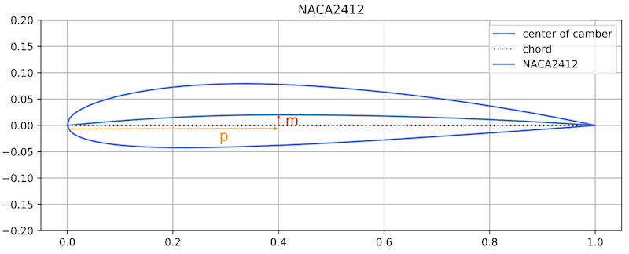

## Methodology to find the shape of airfoil, NACA00XX

$y_t$をNACA00XX（反りがない場合）の翼の厚みの半分の長さとすると

$$ y_t = 5t\left[0.2969\sqrt{x}-0.1260x-0.3516x^2+0.2843x^3-0.1015x^4\right] $$

ここで，$t$は翼長に対する翼の厚みの割合（0.1刻み）$x$は翼弦に沿った点の水平位置。($0<x<1.0$) 翼の上面の座標を$\left(X_U, Y_U\right)$，下面の座標を$\left(X_L, Y_L\right)$とおけば，翼型の曲線の方程式は

$$ X_U=X_L=x, \qquad Y_U= +y_t, Y_L=-y_t $$

翼型をプロットするPythonプログラムを以下に示す。

### Program for NACA00XX

Plot one airfoil

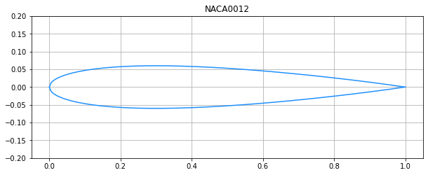

```python
## Import libraries
import numpy as np
import matplotlib.pyplot as plt

## Input Patameters
t = 0.12 # the max tickness as a fraction of the chord [-]
n = 200 # the number of point along the chord [-]

## Find surface of airfoil
x = np.linspace(0, 1, n) # points along the chord [-]

# the tickness of airfoil at given points X [-]
yt = 5.0*t*(0.2969*np.sqrt(x) -0.1260*x-0.3516*x**2 +0.2843*x**3-0.1036*x**4)

# (XU, YU) is for Upper surface
XU = x
YU = +np.abs(yt)

# (XL, YL) is for Lower surface
XL = x
YL = -np.abs(yt)

## Plot surface
f = plt.figure(figsize=(10,5))
ax = f.add_subplot(1,1,1)
ax.set_aspect('equal')
ax.set_ylim([-0.2, 0.2])
ax.grid()
ax.set_title('NACA00{}'.format(int(100*t)))
ax.plot(XU, YU, XL, YL, color="#1e90ff")
#plt.savefig('NACA00{}.png'.format(int(100*t)))
plt.show()
```

Compare mulitple airfoil

```python
def NACA00xx(t, x):
    #     t : the max tickness as a fraction of the chord [-]
    #     x : points along the chord [-]

    #     yt = 5.0*t*(0.2969*np.sqrt(x) -0.1260*x-0.3516*x**2 +0.2843*x**3-0.1036*x**4)

    return 5.0*t*(0.2969*np.sqrt(x) -0.1260*x-0.3516*x**2 +0.2843*x**3-0.1036*x**4)
```

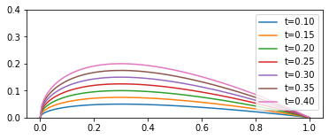

```python
foils = 7
t_val = np.linspace(0.1, 0.4, foils , endpoint = True)
f = plt.figure()
ax = f.add_subplot(1,1,1)
ax.set_aspect('equal')
ax.set_ylim([0, 0.4])

for i in range(0, foils):
    ax.plot(XU, NACA00xx(t_val[i],x), label = 't={:.2f}'.format(t_val[i]))
    ax.legend()


plt.show()
```

## Methodology to find the shape of airfoil, NACAmpXX

以下，翼型のプロット

```python
def Yt(t,x):
    Yt = 5.0*t*(0.2969*np.sqrt(x) -0.1260*x-0.3516*x**2 +0.2843*x**3-0.1036*x**4)

    return Yt

def Yc(m, p, x_front, x_back):
    Yc_front = m/(p**2)*(2*p*x_front - x_front**2)
    Yc_back = m/(1-p)**2*((1-2*p + 2*p*x_back - x_back**2))
    Yc = np.concatenate([Yc_front, Yc_back], 0)

    return Yc

def Theta(m, p, x_front, x_back):
    dycdx_front = 2*m/(p**2)*(p - x_front)
    dycdx_back  = 2*m/(1-p)**2*(p-x_back)
    dycdx = np.concatenate([dycdx_front, dycdx_back], 0)

    Theta = np.arctan(dycdx)
    return Theta

def XUYU(x, yt, yc, phi):
    xU = x -yt*np.sin(phi)
    yU = yc + yt*np.cos(phi)
    return xU, yU

def XLYL(x, yt, yc, phi):
    xL = x +yt*np.sin(phi)
    yL = yc - yt*np.cos(phi)
    return xL, yL
```

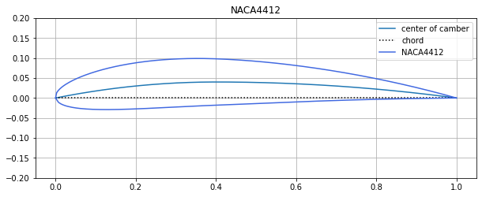

```python
## Import libraries
import numpy as np
import matplotlib.pyplot as plt

## Input Patameters
m  = 0.04 # the max chamber as a faction of ther chord [-]
p  = 0.40 # the location of the max chameer as a faction of ther chord [-]
XX = 0.12 # the max tickness as a fraction of the chord [-]
n = 200 # the number of point along the chord [-]

## Dependent variables
x = np.linspace(0, 1, n) # points along the chord [-]
x_front = x[np.where(x<p)]
x_back = x[np.where((x>p) | (x ==p))]

# Find center of chord
yc = Yc(m, p, x_front, x_back)

# Find tickness of airfoil
yt = Yt(XX, x)

# Find theta
theta = Theta(m, p, x_front, x_back)

# Find (XU, YU) and (XL,YL)
XU, YU = XUYU(x, yt, yc, theta)
XL, YL = XLYL(x, yt, yc, theta)

## Plot airfoil
# Setting of Figure and Axes
f = plt.figure(figsize=(10,5))
ax = f.add_subplot(1,1,1)
ax.set_aspect('equal')
ax.set_ylim([-0.2, 0.2])
ax.set_title("NACA{0}{1}{2}".format(int(100*m),int(10*p),int(100*XX)))
ax.grid(which = 'both')

# Data Plot
ax.plot(x, yc, label = "center of camber")
ax.plot(x, 0*x, color="black", linestyle = ':', label = "chord")
ax.plot(XU, YU, color="#4169e1", label = "NACA{0}{1}{2}".format(int(100*m),int(10*p),int(100*XX)))
ax.plot(XL, YL, color="#4169e1")
ax.legend()
#ax.plot(x, yt, label = "NACA00{}".format(int(100*XX)))
#plt.savefig("NACA{0}{1}{2}.pdf".format(int(100*m),int(10*p),int(100*XX)))
plt.show()
```

## Reference

- Wikipedia, [NACA airfoil](https://en.wikipedia.org/wiki/NACA_airfoil)

戻る